# MD 5 HW

Author

Maddie Drebing

## Chapter 5 - Modern Dive

```r
library(tidyverse)
twitch_data <- read_csv("https://raw.githubusercontent.com/vaiseys/dav-course/main/Data/twitchdata-update.csv")
```

```r
library(janitor)
twitch_data <- clean_names(twitch_data)

# Inspect new names
colnames(twitch_data)
```

```
 [1] "channel"             "watch_time_minutes"  "stream_time_minutes"
 [4] "peak_viewers"        "average_viewers"     "followers"
 [7] "followers_gained"    "views_gained"        "partnered"
[10] "mature"              "language"
```

## Question 1

```r
sample_streamers <- twitch_data %>% sample_n(5)


selected_info <- sample_streamers %>%
  select(channel, average_viewers, followers)

print(selected_info)
```

```
# A tibble: 5 × 3
  channel      average_viewers followers
  <chr>                  <dbl>     <dbl>
1 NBA2KLeague             4264    143535
2 SLAKUN10               18906   1874932
3 stylishnoob4            8485    354579
4 Distortion2             1953    314170
5 RatedEpicz              3336    134757
```

I notice the more average viewers the more followers you have. It is odd for how many followers they have how low the average view count is.

```r
summary_avg_viewers <- summary(twitch_data$`Average viewers`)
summary_followers <- summary(twitch_data$Followers)
print(summary_avg_viewers)
```

```
Length  Class   Mode
     0   NULL   NULL
```

```r
print(summary_followers)
```

```
Length  Class   Mode
     0   NULL   NULL
```

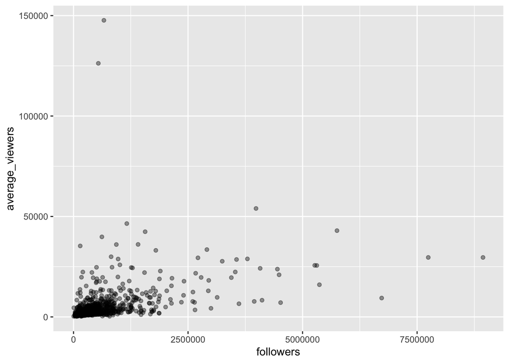

```r
ggplot(twitch_data,
       aes(x = followers,
           y = average_viewers)) +
  geom_point(alpha = .4)
```

There is a lot of over-plotting at the lower numbers of followers and average viewers.

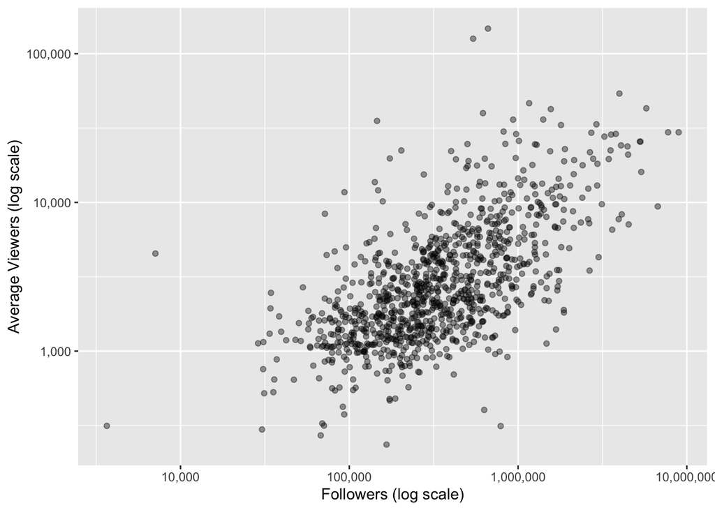

```r
ggplot(twitch_data, aes(x = followers,
                        y = average_viewers)) +
  geom_point(alpha = .4) +
  scale_x_log10(labels = scales::comma_format(scale = 1)) +
  scale_y_log10(labels = scales::comma_format(scale = 1)) +
  labs(x = "Followers (log scale)", y = "Average Viewers (log scale)")
```

There is still a lot of overplotting but it shows more of a relationship between higher viewers and higher followers.

```r
twitch_data <- twitch_data %>%
  mutate(log_viewers = log10(average_viewers),
         log_followers = log10(followers))
```

## Question 2

```r
fit1 <- lm(log_viewers ~ log_followers, data = twitch_data)
```

```r
library(broom)
tidy_summary <- tidy(fit1)
```

coeeficient of .58

## Question 3

```r
library(broom)

pred_data <- augment(fit1)

glimpse(pred_data)
```

```
Rows: 1,000
Columns: 8
$ log_viewers   <dbl> 4.442731, 4.408410, 4.040444, 3.887280, 4.471321, 4.6275…
$ log_followers <dbl> 6.511388, 6.725108, 6.247393, 6.596030, 6.951284, 6.1940…
$ .fitted       <dbl> 4.029761, 4.155534, 3.874400, 4.079572, 4.288638, 3.8430…
$ .resid        <dbl> 0.4129697, 0.2528757, 0.1660436, -0.1922928, 0.1826833, …
$ .hat          <dbl> 0.006194481, 0.008694557, 0.003782169, 0.007126066, 0.01…
$ .sigma        <dbl> 0.3085580, 0.3087321, 0.3087919, 0.3087764, 0.3087820, 0…
$ .cooksd       <dbl> 0.0056128779, 0.0029688873, 0.0005513456, 0.0014026033, …
$ .std.resid    <dbl> 1.3420109, 0.8227954, 0.5389316, -0.6251793, 0.5953620, …
```

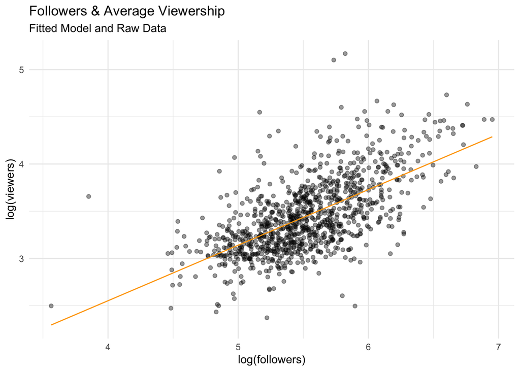

```r
pred_data %>%
  ggplot(aes(x = log_followers,
             y = log_viewers)) +
  geom_jitter(alpha = 0.4) +
  geom_line(aes(x = log_followers,
                y = .fitted),
            col = "orange") +
  theme_minimal() +
  labs(subtitle = "Fitted Model and Raw Data",
       title = "Followers & Average Viewership",
       x = "log(followers)",
       y = "log(viewers)")
```

I think it does describe the relationship well. The line does no stray in any foreign patterns along the data.

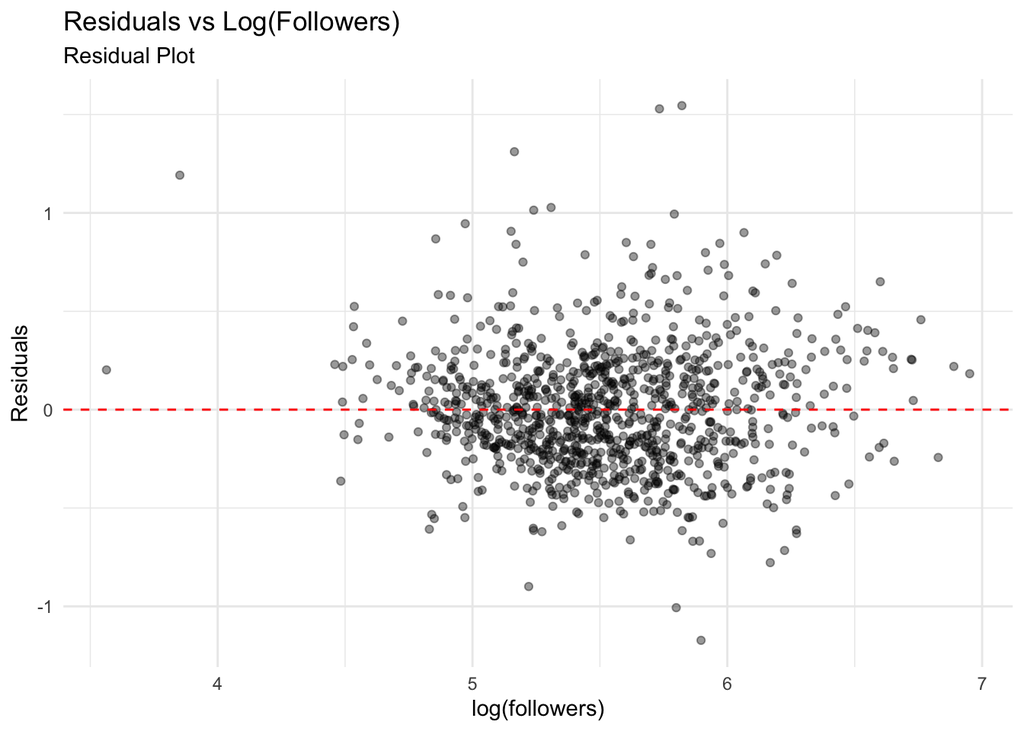

```r
pred_data %>%
  ggplot(aes(x = log_followers,
             y = .resid)) +
  geom_point(alpha = 0.4) +
  geom_hline(yintercept = 0, color = "red", linetype = "dashed") +
  theme_minimal() +
  labs(subtitle = "Residual Plot",
       title = "Residuals vs Log(Followers)",
       x = "log(followers)",
       y = "Residuals")
```

I see a dashed red line going straight through a large sum of points at the 0 Residuals line. There are residuals going along the x axis in a horizontal pattern.

## Question 4

```r
head(twitch_data[c("language", "average_viewers")])
```

```
# A tibble: 6 × 2
  language   average_viewers
  <chr>                <dbl>
1 English              27716
2 English              25610
3 Portuguese           10976
4 English               7714
5 English              29602
6 English              42414
```

```r
summary_avg_viewers <- summary(twitch_data$`Average viewers`)
summary_language <- summary(twitch_data$Language)
print(summary_avg_viewers)
```

```
Length  Class   Mode
     0   NULL   NULL
```

```r
print(summary_language)
```

```
Length  Class   Mode
     0   NULL   NULL
```

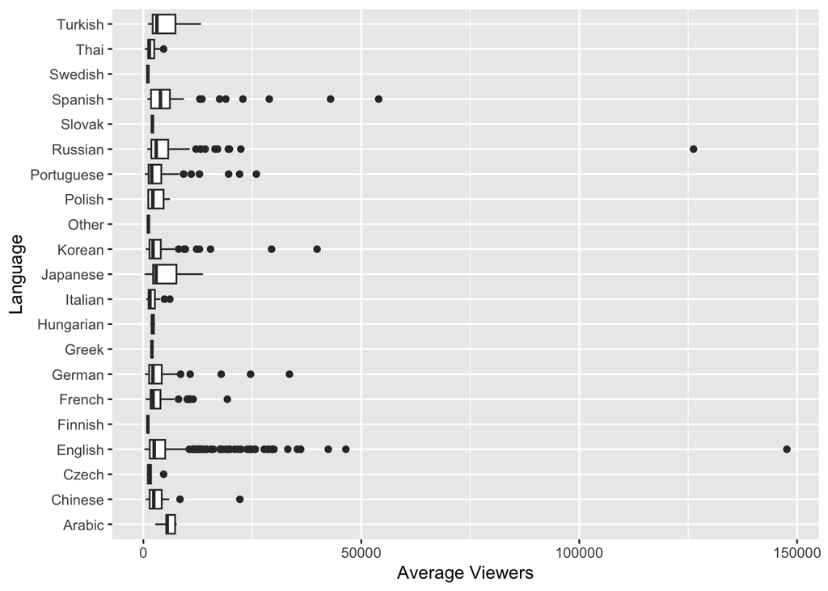

```r
ggplot(twitch_data, aes(x = language, y = average_viewers)) +
  geom_boxplot() +
  labs(x = "Language", y = "Average Viewers") +
coord_flip()
```

## Question 5

```r
twitch_data <- twitch_data %>%
  mutate(language = as.factor(language),
         language = relevel(language, ref = "English"))
```

```r
fit_language <- lm(average_viewers ~ language,
                   data = twitch_data)

summary(fit_language)
```

```
Call:
lm(formula = average_viewers ~ language, data = twitch_data)

Residuals:
   Min     1Q Median     3Q    Max
 -5745  -3317  -2047    173 142530

Coefficients:
                   Estimate Std. Error t value Pr(>|t|)
(Intercept)          5112.8      384.6  13.292   <2e-16 ***
languageArabic        569.4     3807.8   0.150    0.881
languageChinese     -1688.0     1593.7  -1.059    0.290
languageCzech       -3285.1     3479.6  -0.944    0.345
languageFinnish     -4085.8     8479.7  -0.482    0.630
languageFrench      -1606.3     1111.4  -1.445    0.149
languageGerman       -834.6     1269.8  -0.657    0.511
languageGreek       -3151.8     8479.7  -0.372    0.710
languageHungarian   -2972.3     6002.2  -0.495    0.621
languageItalian     -2907.3     2090.2  -1.391    0.165
languageJapanese     -350.2     2706.2  -0.129    0.897
languageKorean      -1198.9     1039.2  -1.154    0.249
languageOther       -3963.8     8479.7  -0.467    0.640
languagePolish      -2207.6     2475.4  -0.892    0.373
languagePortuguese  -1311.9     1150.8  -1.140    0.255
languageRussian      1481.4     1057.2   1.401    0.161
languageSlovak      -3040.8     8479.7  -0.359    0.720
languageSpanish      1336.9     1096.9   1.219    0.223
languageSwedish     -4085.8     8479.7  -0.482    0.630
languageThai        -3101.5     2582.9  -1.201    0.230
languageTurkish      -352.0     1846.5  -0.191    0.849
---
Signif. codes:  0 '***' 0.001 '**' 0.01 '*' 0.05 '.' 0.1 ' ' 1

Residual standard error: 8471 on 979 degrees of freedom
Multiple R-squared:  0.01602,   Adjusted R-squared:  -0.004082
F-statistic: 0.7969 on 20 and 979 DF,  p-value: 0.7194
```

## Question 6

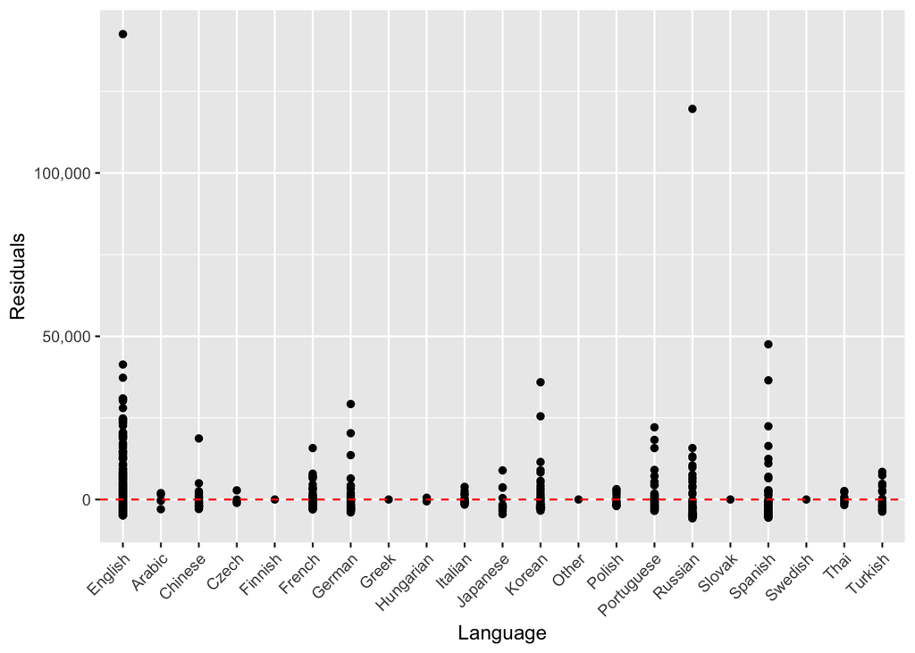

```r
residuals <- resid(fit_language)

residual_data <- data.frame(
  Language = factor(twitch_data$language),
  residuals = residuals
)

ggplot(residual_data, aes(x = Language, y = residuals)) +
  geom_point() +
  geom_hline(yintercept = 0, color = "red", linetype = "dashed") +
  labs(x = "Language", y = "Residuals") +
  theme(axis.text.x = element_text(angle = 45, hjust = 1)) +
  scale_y_continuous(labels = scales::comma_format(scale = 1))
```

English and Russian have the largest discrepancies between actual and predicted values.